# IODS course project

Yuwen Pang

```r
options(knitr.duplicate.label = "allow")
```

# Introduction to Open Data Science - Course Project

# About the project

*Write a short description about the course and add a link to your GitHub repository here. This is an R Markdown (.Rmd) file so you should use R Markdown syntax.*

```r
# This is a so-called "R chunk" where you can write R code.

date()
```

```
## [1] "Thu Dec 09 09:59:51 2021"
```

The text continues here.

1 The course organised quite well for me so far as i have learned also reviewed several R skills, in particular linking the Rstaduio with git.

2 I want to learn the basic statistic practice skill by R and i feel that the course fit my need pretty well.

3 Basically, i am keen on learning/mastering intermediate levels of programming R and then i search the course resource by university course systems and this course was recommend by my colleagues and this time I finally have opportunities to register/enroll.

4 Here is the link to my GitHub repository https://github.com/yuwenpang/IODS-project

# chapter 2 Linear regression

*Describe the work you have done this week and summarize your learning.*

- Describe your work and results clearly.
- Assume the reader has an introductory course level understanding of writing and reading R code as well as statistical methods.
- Assume the reader has no previous knowledge of your data or the more advanced methods you are using.

```r
date()
```

```
## [1] "Thu Dec 09 09:59:51 2021"
```

Here we go again… In this chapter I practiced how to explore the raw data and build a linear regression; (Creat lists with a dash)

- 1 load the data to local memory
- 2 explore the original data by selecting and filter (With R markdown, you can insert R code chunks including table and plots:)

```r
# quick summary of sudent2014 data
# library(dplyr)
library(ggplot2)
library(GGally)
# Load the student2014 data set
stu14 <- read.csv('http://s3.amazonaws.com/assets.datacamp.com/production/course_2218/datasets/learning2014.txt')
# Summary the student2014
summary(stu14)
```

```
##     gender               age           attitude          deep
##  Length:166         Min.   :17.00   Min.   :1.400   Min.   :1.583
##  Class :character   1st Qu.:21.00   1st Qu.:2.600   1st Qu.:3.333
##  Mode  :character   Median :22.00   Median :3.200   Median :3.667
##                     Mean   :25.51   Mean   :3.143   Mean   :3.680
##                     3rd Qu.:27.00   3rd Qu.:3.700   3rd Qu.:4.083
##                     Max.   :55.00   Max.   :5.000   Max.   :4.917
##       stra            surf           points
##  Min.   :1.250   Min.   :1.583   Min.   : 7.00
##  1st Qu.:2.625   1st Qu.:2.417   1st Qu.:19.00
##  Median :3.188   Median :2.833   Median :23.00
##  Mean   :3.121   Mean   :2.787   Mean   :22.72
##  3rd Qu.:3.625   3rd Qu.:3.167   3rd Qu.:27.75
##  Max.   :5.000   Max.   :4.333   Max.   :33.00
```

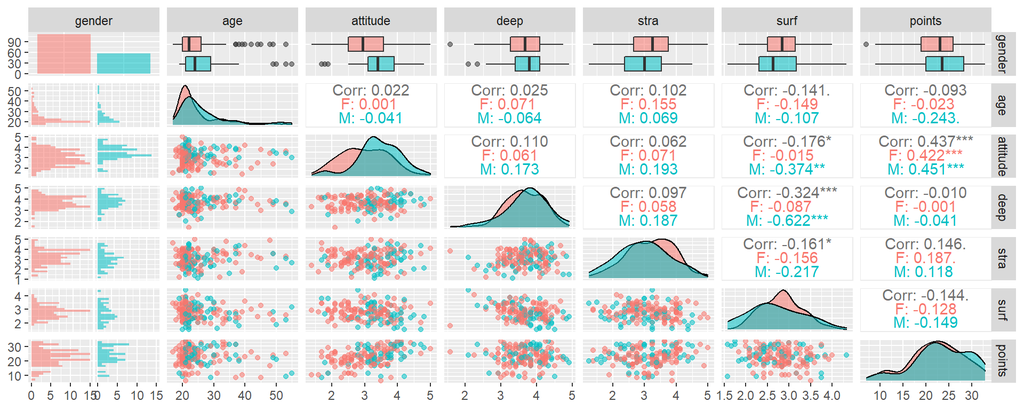

```r
# Print the paris plots
p <- ggpairs(stu14, mapping = aes(col = gender,alpha = 0.3),
         lower = list(combo = wrap("facethist", bins = 20)))
p
```

- 3 before build the regression, the pairs could help we to identify the potential explanatory variables

```r
# As the pair correlation showed,
# the points as respond, the attitude, stra and surf as the explantory variables
model <- lm(points ~ attitude + stra + surf , data = stu14)
summary(model)
```

```
##
## Call:
## lm(formula = points ~ attitude + stra + surf, data = stu14)
##
## Residuals:
##      Min       1Q   Median       3Q      Max
## -17.1550  -3.4346   0.5156   3.6401  10.8952
##
## Coefficients:
##             Estimate Std. Error t value Pr(>|t|)
## (Intercept)  11.0171     3.6837   2.991  0.00322 **
## attitude      3.3952     0.5741   5.913 1.93e-08 ***
## stra          0.8531     0.5416   1.575  0.11716
## surf         -0.5861     0.8014  -0.731  0.46563
## ---
## Signif. codes:  0 '***' 0.001 '**' 0.01 '*' 0.05 '.' 0.1 ' ' 1
##
## Residual standard error: 5.296 on 162 degrees of freedom
## Multiple R-squared:  0.2074, Adjusted R-squared:  0.1927
## F-statistic: 14.13 on 3 and 162 DF,  p-value: 3.156e-08
```

- 4 the model could be conduce perfectly at first time, we could improve it generally

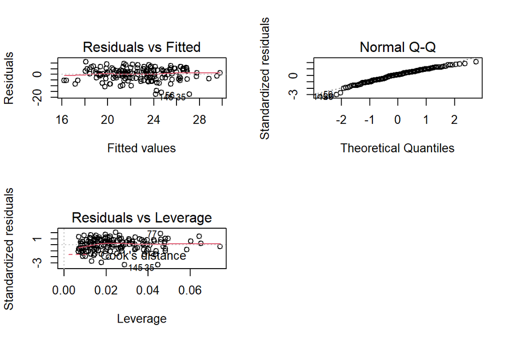

```r
# Examine the model
par(mfrow = c(2,2))
plot(model, which = c(1,2,5))
```

- 5 the improving processes would use diagnostic plots and the summary of models

```r
# rebuild the fitted model
stu14_2 <- stu14[-c(35,56,77,145),] #162*7
model2 <- lm(points ~ attitude + stra , data = stu14_2)
summary(model2)
```

```
##
## Call:
## lm(formula = points ~ attitude + stra, data = stu14_2)
##
## Residuals:
##      Min       1Q   Median       3Q      Max
## -14.3637  -3.3478   0.3832   3.4120  11.2988
##
## Coefficients:
##             Estimate Std. Error t value Pr(>|t|)
## (Intercept)   7.1543     2.1723   3.293  0.00122 **
## attitude      3.8961     0.5124   7.604 2.35e-12 ***
## stra          1.1433     0.4828   2.368  0.01909 *
## ---
## Signif. codes:  0 '***' 0.001 '**' 0.01 '*' 0.05 '.' 0.1 ' ' 1
##
## Residual standard error: 4.747 on 159 degrees of freedom
## Multiple R-squared:  0.2921, Adjusted R-squared:  0.2832
## F-statistic: 32.81 on 2 and 159 DF,  p-value: 1.18e-12
```

- 6 finally, we could get a improved and acceptable models, otherwise, the linear regression would not fit the case, we should look for nonlinear regressions, such as GLM.

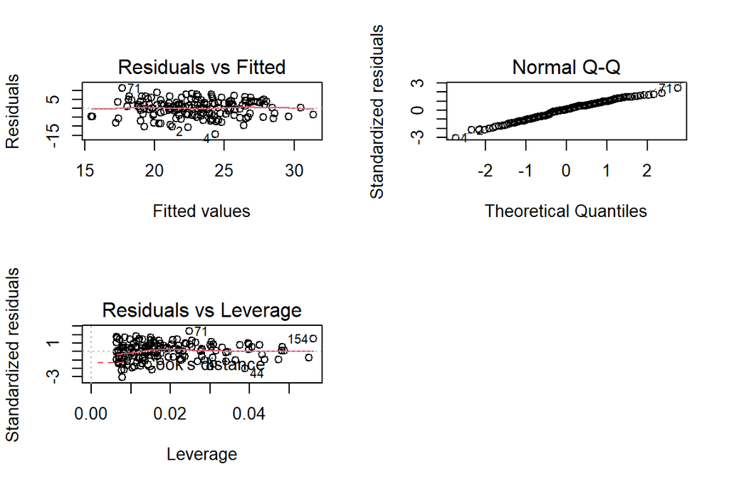

```r
# the r2 has been improved a bit in model2, from 0.21 to 0.29
# the diagnostic plots for model 2
par(mfrow = c(2,2))
plot(model2, which = c(1,2,5))
```

# chapter 3 Logistic regression

```r
date()
```

```
## [1] "Thu Dec 09 10:00:38 2021"
```

## The diary for this chapter, logstic regression

In this chapter I practiced how to explore the raw data and build a Logistic regression; I have learnt and practiced several new functions and systematically understood the logistic regression.

- 1 for binary factor, i could use the logistic regression models, and these processed integrated glm()
- 2 before build the model, the data exploration seems quite important, which could help us to find the most potential parameters. in this case, I identified the potential correlation among high_use, sex, failures and other varietals.
- 3 the model validation: the perdition steps and calculated the probability, prediction, and then the error rate could be reports by user made function. the k-folder validation would be more robust than one-time average error rate, and it also could be used to compare different models.

## Below is the analysis section

### Section 2 Analyzing the regression

### 1 Selecting four variables and establishing the regression

```r
# Library material
library(dplyr)
```

```r
library(ggplot2)
library(GGally)

# Set the working directory
setwd("Z:/Course/Opendata science/IODS-project")

# read previous step exported dataset, alc
stu.csv <- read.csv('data/joint_stu.csv', head = TRUE)
colnames(stu.csv)
```

```
##  [1] "X"          "school"     "sex"        "age"        "address"
##  [6] "famsize"    "Pstatus"    "Medu"       "Fedu"       "Mjob"
## [11] "Fjob"       "reason"     "guardian"   "traveltime" "studytime"
## [16] "schoolsup"  "famsup"     "activities" "nursery"    "higher"
## [21] "internet"   "romantic"   "famrel"     "freetime"   "goout"
## [26] "Dalc"       "Walc"       "health"     "failures"   "paid"
## [31] "absences"   "G1"         "G2"         "G3"         "alc_use"
## [36] "high_use"
```

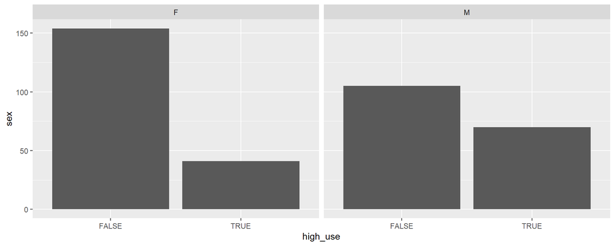

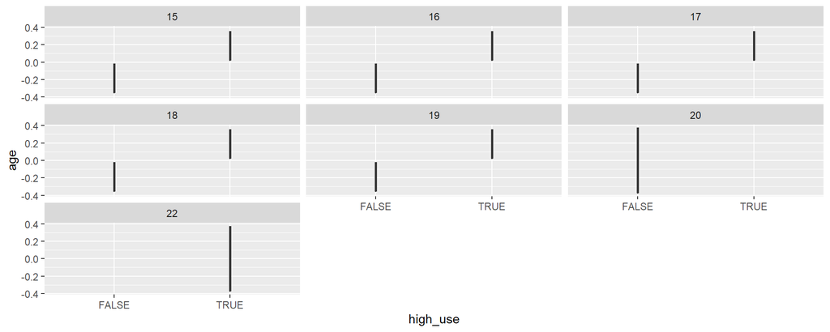

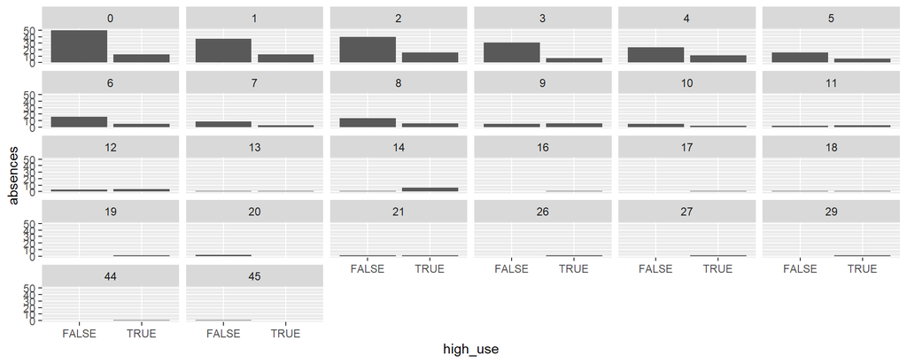

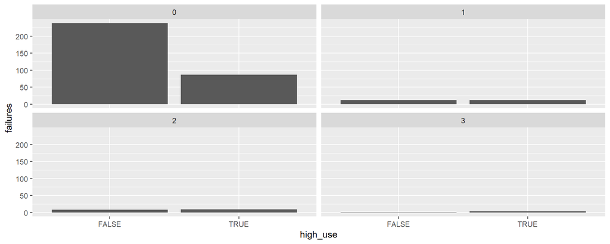

```r
# choose 4 interesting variables
p <- ggpairs(stu.csv[,c(2,3,4,7,13,28,29,31,36)],
             lower = list(combo = wrap("facethist", bins = 20)))
p1 <- ggplot(data = stu.csv, aes(x = high_use)) + ylab("sex") +
  geom_bar() + facet_wrap("sex")
p2 <- ggplot(data = stu.csv, aes(x = high_use)) + ylab("age") +
  geom_boxplot() + facet_wrap("age")
p3 <- ggplot(data = stu.csv, aes(x = high_use)) + ylab("absences") +
  geom_bar() + facet_wrap("absences")
p4 <- ggplot(data = stu.csv, aes(x = high_use)) + ylab("failures") +
  geom_bar() + facet_wrap("failures")

# print plots
# p;
p1;p2;p3;p4
```

```r
# find the model with glm()
m <- glm(high_use ~ failures + absences + sex + age, data = stu.csv, family = "binomial")
summary(m)
```

```
##
## Call:
## glm(formula = high_use ~ failures + absences + sex + age, family = "binomial",
##     data = stu.csv)
##
## Deviance Residuals:
##     Min       1Q   Median       3Q      Max
## -2.1832  -0.8265  -0.6036   1.0200   2.1041
##
## Coefficients:
##             Estimate Std. Error z value Pr(>|z|)
## (Intercept) -3.72535    1.74828  -2.131 0.033100 *
## failures     0.56451    0.21098   2.676 0.007459 **
## absences     0.09019    0.02334   3.864 0.000111 ***
## sexM         1.00045    0.24754   4.042 5.31e-05 ***
## age          0.10850    0.10505   1.033 0.301694
## ---
## Signif. codes:  0 '***' 0.001 '**' 0.01 '*' 0.05 '.' 0.1 ' ' 1
##
## (Dispersion parameter for binomial family taken to be 1)
##
##     Null deviance: 452.04  on 369  degrees of freedom
## Residual deviance: 405.92  on 365  degrees of freedom
## AIC: 415.92
##
## Number of Fisher Scoring iterations: 4
```

```r
# compute odds ratios (OR)
OR <- coef(m) %>% exp
summary(OR)
```

```
##    Min. 1st Qu.  Median    Mean 3rd Qu.    Max.
##  0.0241  1.0944  1.1146  1.3422  1.7586  2.7195
```

```r
# compute confidence intervals (CI)
CI <- confint(m) %>% exp
summary(CI)
```

```
##      2.5 %               97.5 %
##  Min.   :0.0007494   Min.   :0.7203
##  1st Qu.:0.9076445   1st Qu.:1.1484
##  Median :1.0477584   Median :1.3714
##  Mean   :0.9618736   Mean   :2.0769
##  3rd Qu.:1.1692521   3rd Qu.:2.6916
##  Max.   :1.6839636   Max.   :4.4530
```

```r
# print out the odds ratios with their confidence intervals
cbind(OR, CI)
```

```
##                     OR        2.5 %    97.5 %
## (Intercept) 0.02410474 0.0007493589 0.7203136
## failures    1.75858403 1.1692521450 2.6916472
## absences    1.09438639 1.0477584017 1.1483784
## sexM        2.71951309 1.6839636172 4.4530085
## age         1.11460134 0.9076445049 1.3713869
```